# Problem 1 - Variational Auto-Encoder (VAE)

Variational Auto-Encoders (VAEs) are a widely used class of generative models. They are simple to implement and, in contrast to other generative model classes like Generative Adversarial Networks (GANs, see Problem 2), they optimize an explicit maximum likelihood objective to train the model. Finally, their architecture makes them well-suited for unsupervised representation learning, i.e., learning low-dimensional representations of high-dimenionsal inputs, like images, with only self-supervised objectives (data reconstruction in the case of VAEs).

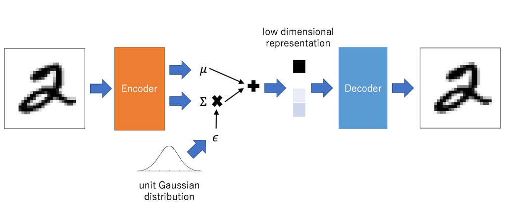

*(image source: https://mlexplained.com/2017/12/28/an-intuitive-explanation-of-variational-autoencoders-vaes-part-1)*

**By working on this problem you will learn and practice the following steps:**

1. Set up a data loading pipeline in PyTorch.
2. Implement, train and visualize an auto-encoder architecture.
3. Extend your implementation to a variational auto-encoder.
4. Learn how to tune the critical beta parameter of your VAE.
5. Inspect the learned representation of your VAE.
6. Extend VAE's generative capabilities by conditioning it on the label you wish to generate.

**Note**: For faster training of the models in this assignment you can enable GPU support in this Colab. Navigate to "Runtime" --> "Change Runtime Type" and set the "Hardware Accelerator" to "GPU". However, you might hit compute limits of the colab free edition. Hence, you might want to debug locally (e.g. in a jupyter notebook) or in a CPU-only runtime on colab.

# 1. MNIST Dataset

We will perform all experiments for this problem using the [MNIST dataset](http://yann.lecun.com/exdb/mnist/), a standard dataset of handwritten digits. The main benefits of this dataset are that it is small and relatively easy to model. It therefore allows for quick experimentation and serves as initial test bed in many papers.

Another benefit is that it is so widely used that PyTorch even provides functionality to automatically download it.

Let's start by downloading the data and visualizing some samples.

```python
import matplotlib.pyplot as plt
%matplotlib inline

# for auto-reloading external modules
# see http://stackoverflow.com/questions/1907993/autoreload-of-modules-in-ipython
%load_ext autoreload
%autoreload 2
```

```python
import torch
import torchvision
device = torch.device('cuda:0' if torch.cuda.is_available() else 'cpu')   # use GPU if available
print(f"Using device: {device}")

# this will automatically download the MNIST training set
mnist_train = torchvision.datasets.MNIST(root='./data',
                                         train=True,
                                         download=True,
                                         transform=torchvision.transforms.ToTensor())
print("\n Download complete! Downloaded {} training examples!".format(len(mnist_train)))
```

```
Using device: cpu

 Download complete! Downloaded 60000 training examples!
```

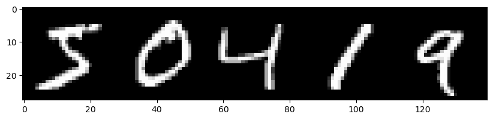

```python
from numpy.random.mtrand import sample
import matplotlib.pyplot as plt
import numpy as np

# Let's display some of the training samples.
sample_images = []
randomize = False # set to False for debugging
num_samples = 5 # simple data sampling for now, later we will use proper DataLoader
if randomize:
  sample_idxs = np.random.randint(low=0,high=len(mnist_train), size=num_samples)
else:
  sample_idxs = list(range(num_samples))

for idx in sample_idxs:
  sample = mnist_train[idx]
  # print(f"Tensor w/ shape {sample[0][0].detach().cpu().numpy().shape} and label {sample[1]}")
  sample_images.append(sample[0][0].data.cpu().numpy())
  # print(sample_images[0]) # Values are in [0, 1]

fig = plt.figure(figsize = (10, 50))
ax1 = plt.subplot(111)
ax1.imshow(np.concatenate(sample_images, axis=1), cmap='gray')
plt.show()
```

# 2. Auto-Encoder

Before implementing the full VAE, we will first implement an **auto-encoder architecture**. Auto-encoders feature the same encoder-decoder architecture as VAEs and therefore also learn a low-dimensional representation of the input data without supervision. In contrast to VAEs they are **fully deterministic** models and do not employ variational inference for optimization.

The **architecture** is very simple: we will encode the input image into a low-dimensional representation using fully connected layers for the encoder. This results in a low-dimensional representation of the input image. This representation will get decoded back into the dimensionality of the input image using a decoder network that mirrors the architecture of the encoder. The whole model is trained by **minimizing a reconstruction loss** between the input and the decoded image.

Intuitively, the **auto-encoder needs to compress the information contained in the input image** into a much lower dimensional representation (e.g. 28x28=784px vs. nz embedding dimensions for our MNIST model). This is possible since the information captured in the pixels is *highly redundant*. E.g. encoding an MNIST image requires <4 bits to encode which of the 10 possible digits is displayed and a few additional bits to capture information about shape and orientation. This is much less than the $255^{28\cdot 28}$ bits of information that could be theoretically captured in the input image.

Learning such a **compressed representation can make downstream task learning easier**. For example, learning to add two numbers based on the inferred digits is much easier than performing the task based on two piles of pixel values that depict the digits.

In the following, we will first define the architecture of encoder and decoder and then train the auto-encoder model.

## Defining the Auto-Encoder Architecture [6pt]

```python
import torch.nn as nn

# Prob1-1: Let's define encoder and decoder networks
class Encoder(nn.Module):
  def __init__(self, nz, input_size):
    super().__init__()
    self.input_size = input_size
    ################################# TODO #########################################
    # Create the network architecture using a nn.Sequential module wrapper.        #
    # Encoder Architecture:                                                        #
    # - input_size -> 256                                                          #
    # - ReLU                                                                       #
    # - 256 -> 64                                                                  #
    # - ReLU                                                                       #
    # - 64 -> nz                                                                   #
    # HINT: Verify the shapes of intermediate layers by running partial networks   #
    #        (with the next notebook cell) and visualizing the output shapes.      #
    ################################################################################
    self.net = nn.Sequential(
        nn.Linear(input_size, 256),
        nn.ReLU(),
        nn.Linear(256, 64),
        nn.ReLU(),
        nn.Linear(64, nz)
    )
    ################################ END TODO #######################################

  def forward(self, x):
    return self.net(x)


class Decoder(nn.Module):
  def __init__(self, nz, output_size):
    super().__init__()
    self.output_size = output_size
    ################################# TODO #########################################
    # Create the network architecture using a nn.Sequential module wrapper.        #
    # Decoder Architecture (mirrors encoder architecture):                         #
    # - nz -> 64                                                                   #
    # - ReLU                                                                       #
    # - 64 -> 256                                                                  #
    # - ReLU                                                                       #
    # - 256 -> output_size                                                         #
    ################################################################################
    self.net = nn.Sequential(
        nn.Linear(nz, 64),
        nn.ReLU(),
        nn.Linear(64, 256),
        nn.ReLU(),
        nn.Linear(256, output_size),
        nn.Sigmoid(),
    )
    ################################ END TODO #######################################

  def forward(self, z):
    return self.net(z).reshape(-1, 1, self.output_size)
```

## Testing the Auto-Encoder Forward Pass

```python
# To test your encoder/decoder, let's encode/decode some sample images
# first, make a PyTorch DataLoader object to sample data batches
batch_size = 64
nworkers = 2        # number of workers used for efficient data loading

####################################################################################
# Create a PyTorch DataLoader object for efficiently generating training batches.  #
# Make sure that the data loader automatically shuffles the training dataset.      #
# Consider only *full* batches of data, to avoid torch errrors.              #
# The DataLoader wraps the MNIST dataset class we created earlier.           #
#       Use the given batch_size and number of data loading workers when creating  #
#       the DataLoader. https://pytorch.org/docs/stable/data.html                  #
####################################################################################
mnist_data_loader = torch.utils.data.DataLoader(mnist_train,
                                                batch_size=batch_size,
                                                shuffle=True,
                                                num_workers=nworkers,
                                                drop_last=True)
####################################################################################

# now we can run a forward pass for encoder and decoder and check the produced shapes
in_size = out_size = 28*28 # image size
nz = 32          # dimensionality of the learned embedding
encoder = Encoder(nz=nz, input_size=in_size)
decoder = Decoder(nz=nz, output_size=out_size)
for sample_img, sample_label in mnist_data_loader: # loads a batch of data
  input = sample_img.reshape([batch_size, in_size])
  print(f'{sample_img.shape=}, {type(sample_img)}, {input.shape=}')
  enc = encoder(input)
  print(f"Shape of encoding vector (should be [batch_size, nz]): {enc.shape}")
  dec = decoder(enc)
  print("Shape of decoded image (should be [batch_size, 1, out_size]): {}.".format(dec.shape))
  break

del input, enc, dec, encoder, decoder, nworkers # remove to avoid confusion later
```

```
sample_img.shape=torch.Size([64, 1, 28, 28]), <class 'torch.Tensor'>, input.shape=torch.Size([64, 784])
Shape of encoding vector (should be [batch_size, nz]): torch.Size([64, 32])
Shape of decoded image (should be [batch_size, 1, out_size]): torch.Size([64, 1, 784]).
```

Now that we defined encoder and decoder network our architecture is nearly complete. However, before we start training, we can wrap encoder and decoder into an auto-encoder class for easier handling.

```python
class AutoEncoder(nn.Module):
  def __init__(self, nz):
    super().__init__()
    self.encoder = Encoder(nz=nz, input_size=in_size)
    self.decoder = Decoder(nz=nz, output_size=out_size)

  def forward(self, x):
    enc = self.encoder(x)
    return self.decoder(enc)

  def reconstruct(self, x):
    """Only used later for visualization."""
    enc = self.encoder(x)
    flattened = self.decoder(enc)
    image = flattened.reshape(-1, 28, 28)
    return image
```

## Setting up the Auto-Encoder Training Loop [6pt]

After implementing the network architecture, we can now set up the training loop and run training.

```python
# Prob1-2
epochs = 10
learning_rate = 1e-3

# build AE model
print(f'Device available {device}')
ae_model = AutoEncoder(nz).to(device)    # transfer model to GPU if available
ae_model = ae_model.train()   # set model in train mode (eg batchnorm params get updated)

# build optimizer and loss function
####################################### TODO #######################################
# Build the optimizer and loss classes. For the loss you can use a loss layer      #
# from the torch.nn package. We recommend binary cross entropy.                    #
# HINT: We will use the Adam optimizer (learning rate given above, otherwise       #
#       default parameters).                                                       #
# NOTE: We could also use alternative losses like MSE and cross entropy, depending #
#       on the assumptions we are making about the output distribution.            #
####################################################################################
optimizer = torch.optim.Adam(ae_model.parameters(), lr=learning_rate)
loss_function = nn.BCELoss()
#################################### END TODO #######################################

train_it = 0
for ep in range(epochs):
  print("Run Epoch {}".format(ep))
  ####################################### TODO #######################################
  # Implement the main training loop for the auto-encoder model.                     #
  # HINT: Your training loop should sample batches from the data loader, run the     #
  #       forward pass of the AE, compute the loss, perform the backward pass and    #
  #       perform one gradient step with the optimizer.                              #
  # HINT: Don't forget to erase old gradients before performing the backward pass.   #
  ####################################################################################
  for data, _ in mnist_data_loader:
    data = data.to(device)

    data = data.view(data.size(0), -1)

    optimizer.zero_grad()
    reconstructed_data = ae_model(data)
    flattened_target = data.view(data.size(0), -1)
    flattened_input = reconstructed_data.squeeze()

    flattened_input = flattened_input.view(flattened_target.size())

    rec_loss = loss_function(flattened_input, flattened_target)
    rec_loss.backward()
    optimizer.step()

    if train_it % 100 == 0:
      print("It {}: Reconstruction Loss: {}".format(train_it, rec_loss))
    train_it += 1
  #################################### END TODO #####################################

print("Done!")
del epochs, learning_rate, sample_img, train_it, rec_loss #, opt
```

```
Device available cpu
Run Epoch 0
It 0: Reconstruction Loss: 0.6949727535247803
It 100: Reconstruction Loss: 0.25796398520469666
It 200: Reconstruction Loss: 0.22850316762924194
It 300: Reconstruction Loss: 0.20847740769386292
It 400: Reconstruction Loss: 0.17884118854999542
It 500: Reconstruction Loss: 0.15590590238571167
It 600: Reconstruction Loss: 0.15327247977256775
It 700: Reconstruction Loss: 0.13752718269824982
It 800: Reconstruction Loss: 0.1388983428478241
It 900: Reconstruction Loss: 0.14905807375907898
Run Epoch 1
It 1000: Reconstruction Loss: 0.13757896423339844
It 1100: Reconstruction Loss: 0.13140642642974854
It 1200: Reconstruction Loss: 0.1273401379585266
It 1300: Reconstruction Loss: 0.1261572390794754
It 1400: Reconstruction Loss: 0.13360457122325897
It 1500: Reconstruction Loss: 0.12318161875009537
It 1600: Reconstruction Loss: 0.12839478254318237
It 1700: Reconstruction Loss: 0.11961037665605545
It 1800: Reconstruction Loss: 0.12296384572982788
Run Epoch 2
It 1900: Reconstruction Loss: 0.11378539353609085
It 2000: Reconstruction Loss: 0.11495272070169449
It 2100: Reconstruction Loss: 0.11769262701272964
It 2200: Reconstruction Loss: 0.10400655120611191
It 2300: Reconstruction Loss: 0.11373072862625122
It 2400: Reconstruction Loss: 0.11491018533706665
It 2500: Reconstruction Loss: 0.11336453258991241
It 2600: Reconstruction Loss: 0.10164064913988113
It 2700: Reconstruction Loss: 0.11790469288825989
It 2800: Reconstruction Loss: 0.10921571403741837
Run Epoch 3
It 2900: Reconstruction Loss: 0.10965534299612045
It 3000: Reconstruction Loss: 0.1166471391916275
It 3100: Reconstruction Loss: 0.10160356014966965
It 3200: Reconstruction Loss: 0.10526562482118607
It 3300: Reconstruction Loss: 0.10507624596357346
It 3400: Reconstruction Loss: 0.10538803786039352
```

[output cut: 51 more lines]

```
It 8100: Reconstruction Loss: 0.0869767814874649
It 8200: Reconstruction Loss: 0.08995246887207031
It 8300: Reconstruction Loss: 0.09072190523147583
It 8400: Reconstruction Loss: 0.0936783105134964
Run Epoch 9
It 8500: Reconstruction Loss: 0.08946443349123001
It 8600: Reconstruction Loss: 0.08789670467376709
It 8700: Reconstruction Loss: 0.09601713716983795
It 8800: Reconstruction Loss: 0.09266302734613419
It 8900: Reconstruction Loss: 0.08592844754457474
It 9000: Reconstruction Loss: 0.08593285083770752
It 9100: Reconstruction Loss: 0.0808083638548851
It 9200: Reconstruction Loss: 0.08610250800848007
It 9300: Reconstruction Loss: 0.0902949720621109
Done!
```

## Verifying reconstructions

Now that we trained the auto-encoder we can visualize some of the reconstructions on the test set to verify that it is converged and did not overfit. **Before continuing, make sure that your auto-encoder is able to reconstruct these samples near-perfectly.**

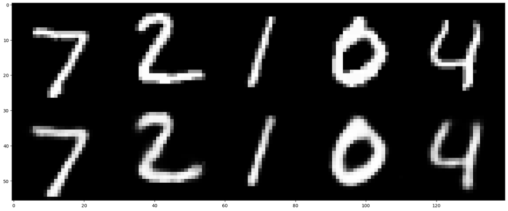

```python
# visualize test data reconstructions
def vis_reconstruction(model, randomize=False):
  # download MNIST test set + build Dataset object
  mnist_test = torchvision.datasets.MNIST(root='./data',
                                          train=False,
                                          download=True,
                                          transform=torchvision.transforms.ToTensor())
  model.eval()      # set model in evalidation mode (eg freeze batchnorm params)
  num_samples = 5
  if randomize:
    sample_idxs = np.random.randint(low=0,high=len(mnist_test), size=num_samples)
  else:
    sample_idxs = list(range(num_samples))

  input_imgs, test_reconstructions = [], []
  for idx in sample_idxs:
    sample = mnist_test[idx]
    input_img = np.asarray(sample[0])
    input_flat = input_img.reshape(784)
    reconstruction = model.reconstruct(torch.tensor(input_flat, device=device))

    input_imgs.append(input_img[0])
    test_reconstructions.append(reconstruction[0].data.cpu().numpy())
    # print(f'{input_img[0].shape=}\t{reconstruction.shape}')

  fig = plt.figure(figsize = (20, 50))
  ax1 = plt.subplot(111)
  ax1.imshow(np.concatenate([np.concatenate(input_imgs, axis=1),
                            np.concatenate(test_reconstructions, axis=1)], axis=0), cmap='gray')
  plt.show()

vis_reconstruction(ae_model, randomize=False) # set randomize to False for debugging
```

## Sampling from the Auto-Encoder [2pt]

To test whether the auto-encoder is useful as a generative model, we can use it like any other generative model: draw embedding samples from a prior distribution and decode them through the decoder network. We will choose a unit Gaussian prior to allow for easy comparison to the VAE later.

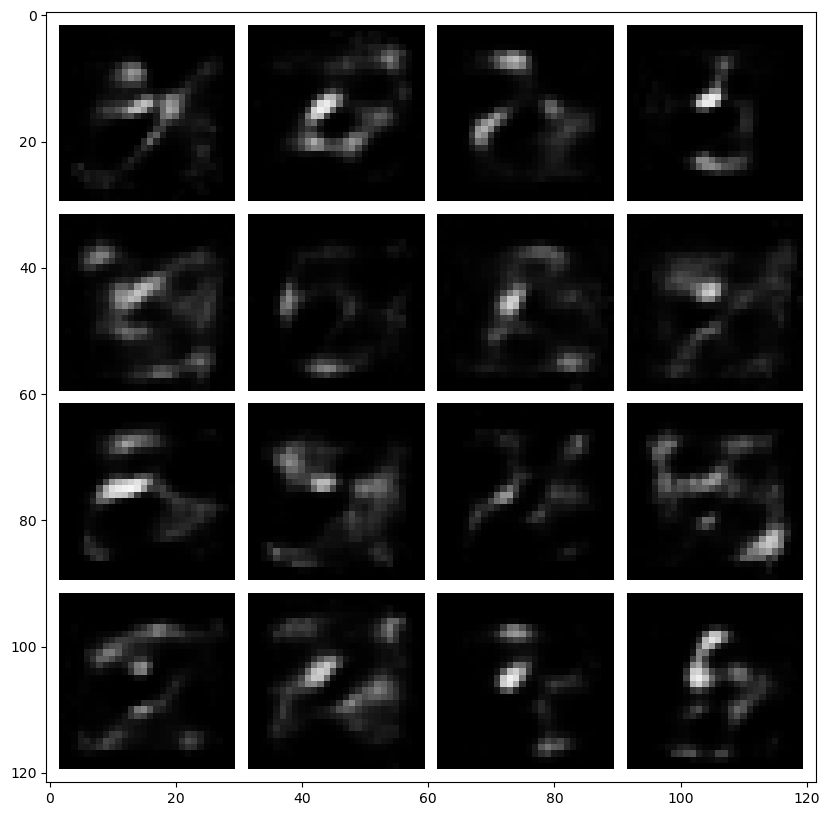

```python
# we will sample N embeddings, then decode and visualize them
def vis_samples(model):
  ####################################### TODO #######################################
  # Prob1-3 Sample embeddings from a diagonal unit Gaussian distribution and decode them     #
  # using the model.                                                                 #
  # HINT: The sampled embeddings should have shape [batch_size, nz]. Diagonal unit   #
  #       Gaussians have mean 0 and a covariance matrix with ones on the diagonal    #
  #       and zeros everywhere else.                                                 #
  # HINT: If you are unsure whether you sampled the correct distribution, you can    #
  #       sample a large batch and compute the empirical mean and variance using the #
  #       .mean() and .var() functions.                                              #
  # HINT: You can directly use model.decoder() to decode the samples.                #
  ####################################################################################
  batch_size = 16
  nz = model.decoder.net[0].in_features

  embeddings = torch.randn(batch_size, nz).to(device)
  decoded_samples = model.decoder(embeddings)
  decoded_samples = decoded_samples.view(batch_size, 1, 28, 28)
  #################################### END TODO ######################################

  fig = plt.figure(figsize = (10, 10))
  ax1 = plt.subplot(111)
  ax1.imshow(torchvision.utils.make_grid(decoded_samples[:16], nrow=4, pad_value=1.)\
                .data.cpu().numpy().transpose(1, 2, 0), cmap='gray')
  plt.show()

vis_samples(ae_model)
```

> **Prob1-3 continued: Inline Question: Describe your observations, why do you think they occur? [2pt]** (max 150 words)

> **Answer:** Auto-encoder does not learn the distribution of the training data unlike VAE. This can lead to unorganized and messy latent spaces, whhich is low-dimensional. They're effective at generating samples that lie within the encoded space, but when we tried generating new samples from embeddings outside of the encoded space, the results became random and poorly defined like we see at the top. So we can see the jumbled and not-well defined digit.

# 3. Variational Auto-Encoder (VAE)

Variational auto-encoders use a very similar architecture to deterministic auto-encoders, but are inherently storchastic models, i.e. we perform a stochastic sampling operation during the forward pass, leading to different different outputs every time we run the network for the same input. This sampling is required to optimize the VAE objective also known as the evidence lower bound (ELBO):

$$ p(x) > \underbrace{\mathbb{E}_{z\sim q(z\vert x)} p(x \vert z)}_{\text{reconstruction}} - \underbrace{D_{\text{KL}}\big(q(z \vert x), p(z)\big)}_{\text{prior divergence}} $$

Here, $D_{\text{KL}}(q, p)$ denotes the Kullback-Leibler (KL) divergence between the posterior distribution $q(z \vert x)$, i.e. the output of our encoder, and $p(z)$, the prior over the embedding variable $z$, which we can choose freely.

For simplicity, we will choose a unit Gaussian prior again. The first term is the reconstruction term we already know from training the auto-encoder. When assuming a Gaussian output distribution for both encoder $q(z \vert x)$ and decoder $p(x \vert z)$ the objective reduces to:

$$ \mathcal{L}_{\text{VAE}} = \sum_{x\sim \mathcal{D}} \mathcal{L}_{\text{rec}}(x, \hat{x}) - \beta \cdot D_{\text{KL}}\big(\mathcal{N}(\mu_q, \sigma_q), \mathcal{N}(0, I)\big) $$

Here, $\hat{x}$ is the reconstruction output of the decoder. In comparison to the auto-encoder objective, the VAE adds a regularizing term between the output of the encoder and a chosen prior distribution, effectively forcing the encoder output to not stray too far from the prior during training. As a result the decoder gets trained with samples that look pretty similar to samples from the prior, which will hopefully allow us to generate better images when using the VAE as a generative model and actually feeding it samples from the prior (as we have done for the AE before).

The coefficient $\beta$ is a scalar weighting factor that trades off between reconstruction and regularization objective. We will investigate the influence of this factor in out experiments below.

If you need a refresher on VAEs you can check out this tutorial paper: https://arxiv.org/abs/1606.05908

### Reparametrization Trick

The sampling procedure inside the VAE's forward pass for obtaining a sample $z$ from the posterior distribution $q(z \vert x)$, when implemented naively, is non-differentiable. However, since $q(z\vert x)$ is parametrized with a Gaussian function, there is a simple trick to obtain a differentiable sampling operator, known as the *reparametrization trick*.

Instead of directly sampling $z \sim \mathcal{N}(\mu_q, \sigma_q)$ we can "separate" the network's predictions and the random sampling by computing the sample as:

$$ z = \mu_q + \sigma_q * \epsilon , \quad \epsilon \sim \mathcal{N}(0, I) $$

Note that in this equation, the sample $z$ is computed as a deterministic function of the network's predictions $\mu_q$ and $\sigma_q$ and therefore allows to propagate gradients through the sampling procedure.

**Note**: While in the equations above the encoder network parametrizes the standard deviation $\sigma_q$ of the Gaussian posterior distribution, in practice we usually parametrize the **logarithm of the standard deviation** $\log \sigma_q$ for numerical stability. Before sampling $z$ we will then exponentiate the network's output to obtain $\sigma_q$.

## Defining the VAE Model [7pt]

```python
def kl_divergence(mu1, log_sigma1, mu2, log_sigma2):
  """Computes KL[p||q] between two Gaussians defined by [mu, log_sigma]."""
  return (log_sigma2 - log_sigma1) + (torch.exp(log_sigma1) ** 2 + (mu1 - mu2) ** 2) \
               / (2 * torch.exp(log_sigma2) ** 2) - 0.5

# Prob1-4
class VAE(nn.Module):
  def __init__(self, nz, beta=1.0):
    super().__init__()
    self.beta = beta          # factor trading off between two loss components
    ####################################### TODO #######################################
    # Instantiate Encoder and Decoder.                                                 #
    # HINT: Remember that the encoder is now parametrizing a Gaussian distribution's   #
    #       mean and log_sigma, so the dimensionality of the output needs to           #
    #       double. The decoder works with an embedding sampled from this output.  #
    ####################################################################################
    input_size = 28 * 28
    self.encoder = Encoder(nz * 2, input_size)
    self.decoder = Decoder(nz, input_size)
    #################################### END TODO ######################################

  def forward(self, x):
    ####################################### TODO #######################################
    # Implement the forward pass of the VAE.                                           #
    # HINT: Your code should implement the following steps:                            #
    #          1. encode input x, split encoding into mean and log_sigma of Gaussian   #
    #          2. sample z from inferred posterior distribution using                  #
    #             reparametrization trick                                              #
    #          3. decode the sampled z to obtain the reconstructed image               #
    ####################################################################################
    if len(x.shape) == 3:
        x = x.unsqueeze(0)

    x_flattened = x.view(-1, 28 * 28)
    q = self.encoder(x_flattened)
    mu, log_sigma = q.chunk(2, dim=1)
    z = mu + torch.randn_like(log_sigma) * torch.exp(log_sigma)
    reconstruction = self.decoder(z).view(x.size(0), -1, 28, 28)
    # reconstruction = self.decoder(z)
    #################################### END TODO ######################################

    return {'q': q,
            'rec': reconstruction}

  def loss(self, x, outputs):
    ####################################### TODO #######################################
    # Implement the loss computation of the VAE.                                       #
    # HINT: Your code should implement the following steps:                            #
    #          1. compute the image reconstruction loss, similar to AE loss above      #
    #          2. compute the KL divergence loss between the inferred posterior        #
    #             distribution and a unit Gaussian prior; you can use the provided     #
    #             function above for computing the KL divergence between two Gaussians #
    #             parametrized by mean and log_sigma                                   #
    # HINT: Make sure to compute the KL divergence in the correct order since it is    #
    #       not symmetric!!  ie. KL(p, q) != KL(q, p)                                  #
    ####################################################################################
    q = outputs['q']
    mu, log_sigma = q.chunk(2, dim=1)
    flattened_target = x.view(x.size(0), -1)
    # flattened_input = outputs['rec'].squeeze()
    flattened_input = outputs['rec'].view(x.size(0), -1)

    bce_loss = nn.BCELoss()
    rec_loss = bce_loss(flattened_input, flattened_target)
    # bce_with_logits_loss = nn.BCEWithLogitsLoss()
    # rec_loss = bce_with_logits_loss(flattened_input, flattened_target)

    kl_loss = kl_divergence(mu, log_sigma, torch.zeros_like(mu), torch.zeros_like(log_sigma)).sum(1).mean()
    #################################### END TODO ######################################

    # return weighted objective
    return rec_loss + self.beta * kl_loss, \
           {'rec_loss': rec_loss, 'kl_loss': kl_loss}

  def reconstruct(self, x):
    """Use mean of posterior estimate for visualization reconstruction."""
    ####################################### TODO #######################################
    # This function is used for visualizing reconstructions of our VAE model. To       #
    # obtain the maximum likelihood estimate we bypass the sampling procedure of the   #
    # inferred latent and instead directly use the mean of the inferred posterior.     #
    # HINT: encode the input image and then decode the mean of the posterior to obtain #
    #       the reconstruction.                                                        #
    ####################################################################################
    q = self.encoder(x.view(-1, 28 * 28))
    mu, log_sigma = q.chunk(2, dim=1)
    reconstructed = self.decoder(mu)
    # image = reconstructed.view(x.size(0), 1, 28, 28)
    image = reconstructed.view(-1, 28, 28)
    # image = reconstructed.view(x.size(0), 28, 28)
    # image = reconstructed.view(-1, 1, 28, 28)
    #################################### END TODO ######################################

    return image
```

## Setting up the VAE Training Loop [4pt]

Let's start training the VAE model! We will first verify our implementation by setting $\beta = 0$.

```
Running 5 epochs with beta=0
Run Epoch 0
It 0: Total Loss: 0.6945262551307678, 	 Rec Loss: 0.6945262551307678,	 KL Loss: 0.35627713799476624
It 100: Total Loss: 0.2658122777938843, 	 Rec Loss: 0.2658122777938843,	 KL Loss: 20.757680892944336
It 200: Total Loss: 0.2209617644548416, 	 Rec Loss: 0.2209617644548416,	 KL Loss: 85.32701110839844
It 300: Total Loss: 0.19040438532829285, 	 Rec Loss: 0.19040438532829285,	 KL Loss: 160.19187927246094
It 400: Total Loss: 0.18242186307907104, 	 Rec Loss: 0.18242186307907104,	 KL Loss: 300.89471435546875
It 500: Total Loss: 0.1568736582994461, 	 Rec Loss: 0.1568736582994461,	 KL Loss: 361.32562255859375
It 600: Total Loss: 0.14887173473834991, 	 Rec Loss: 0.14887173473834991,	 KL Loss: 441.897216796875
It 700: Total Loss: 0.14604564011096954, 	 Rec Loss: 0.14604564011096954,	 KL Loss: 498.2046813964844
It 800: Total Loss: 0.1404954195022583, 	 Rec Loss: 0.1404954195022583,	 KL Loss: 534.5443115234375
It 900: Total Loss: 0.1289876252412796, 	 Rec Loss: 0.1289876252412796,	 KL Loss: 595.1929931640625
Run Epoch 1
It 1000: Total Loss: 0.1257178783416748, 	 Rec Loss: 0.1257178783416748,	 KL Loss: 633.7476806640625
It 1100: Total Loss: 0.12270642071962357, 	 Rec Loss: 0.12270642071962357,	 KL Loss: 602.4722900390625
It 1200: Total Loss: 0.13103757798671722, 	 Rec Loss: 0.13103757798671722,	 KL Loss: 646.0119018554688
It 1300: Total Loss: 0.13318873941898346, 	 Rec Loss: 0.13318873941898346,	 KL Loss: 667.654296875
It 1400: Total Loss: 0.13051633536815643, 	 Rec Loss: 0.13051633536815643,	 KL Loss: 685.17724609375
It 1500: Total Loss: 0.10938762873411179, 	 Rec Loss: 0.10938762873411179,	 KL Loss: 737.3150024414062
It 1600: Total Loss: 0.11327254772186279, 	 Rec Loss: 0.11327254772186279,	 KL Loss: 679.2926025390625
It 1700: Total Loss: 0.12144523113965988, 	 Rec Loss: 0.12144523113965988,	 KL Loss: 674.7216796875
It 1800: Total Loss: 0.11758607625961304, 	 Rec Loss: 0.11758607625961304,	 KL Loss: 773.4210815429688
Run Epoch 2
It 1900: Total Loss: 0.11235407739877701, 	 Rec Loss: 0.11235407739877701,	 KL Loss: 731.7401123046875
It 2000: Total Loss: 0.10908526182174683, 	 Rec Loss: 0.10908526182174683,	 KL Loss: 728.5457763671875
It 2100: Total Loss: 0.10786165297031403, 	 Rec Loss: 0.10786165297031403,	 KL Loss: 731.0780029296875
It 2200: Total Loss: 0.11550039052963257, 	 Rec Loss: 0.11550039052963257,	 KL Loss: 727.1239013671875
It 2300: Total Loss: 0.1101563572883606, 	 Rec Loss: 0.1101563572883606,	 KL Loss: 794.376220703125
It 2400: Total Loss: 0.10743071138858795, 	 Rec Loss: 0.10743071138858795,	 KL Loss: 801.513427734375
It 2500: Total Loss: 0.10130424797534943, 	 Rec Loss: 0.10130424797534943,	 KL Loss: 760.200439453125
It 2600: Total Loss: 0.10522911697626114, 	 Rec Loss: 0.10522911697626114,	 KL Loss: 811.762939453125
It 2700: Total Loss: 0.1038881242275238, 	 Rec Loss: 0.1038881242275238,	 KL Loss: 831.7936401367188
It 2800: Total Loss: 0.10787371546030045, 	 Rec Loss: 0.10787371546030045,	 KL Loss: 791.0057373046875
Run Epoch 3
It 2900: Total Loss: 0.10540059208869934, 	 Rec Loss: 0.10540059208869934,	 KL Loss: 813.42529296875
It 3000: Total Loss: 0.10583484172821045, 	 Rec Loss: 0.10583484172821045,	 KL Loss: 862.3594360351562
It 3100: Total Loss: 0.09888956695795059, 	 Rec Loss: 0.09888956695795059,	 KL Loss: 814.8705444335938
It 3200: Total Loss: 0.09335807710886002, 	 Rec Loss: 0.09335807710886002,	 KL Loss: 842.5789794921875
It 3300: Total Loss: 0.10088786482810974, 	 Rec Loss: 0.10088786482810974,	 KL Loss: 719.55029296875
It 3400: Total Loss: 0.09824459999799728, 	 Rec Loss: 0.09824459999799728,	 KL Loss: 862.8773193359375
It 3500: Total Loss: 0.10682926326990128, 	 Rec Loss: 0.10682926326990128,	 KL Loss: 835.6175537109375
It 3600: Total Loss: 0.10032615810632706, 	 Rec Loss: 0.10032615810632706,	 KL Loss: 817.8833618164062
It 3700: Total Loss: 0.09299898147583008, 	 Rec Loss: 0.09299898147583008,	 KL Loss: 801.9071044921875
Run Epoch 4
It 3800: Total Loss: 0.09599417448043823, 	 Rec Loss: 0.09599417448043823,	 KL Loss: 844.6107177734375
It 3900: Total Loss: 0.09335089474916458, 	 Rec Loss: 0.09335089474916458,	 KL Loss: 820.4599609375
It 4000: Total Loss: 0.0983320027589798, 	 Rec Loss: 0.0983320027589798,	 KL Loss: 800.2857055664062
It 4100: Total Loss: 0.09486544132232666, 	 Rec Loss: 0.09486544132232666,	 KL Loss: 835.1856079101562
It 4200: Total Loss: 0.09364287555217743, 	 Rec Loss: 0.09364287555217743,	 KL Loss: 817.1142578125
It 4300: Total Loss: 0.09466607123613358, 	 Rec Loss: 0.09466607123613358,	 KL Loss: 866.3169555664062
It 4400: Total Loss: 0.09575194120407104, 	 Rec Loss: 0.09575194120407104,	 KL Loss: 880.8576049804688
It 4500: Total Loss: 0.09277687221765518, 	 Rec Loss: 0.09277687221765518,	 KL Loss: 873.4346923828125
It 4600: Total Loss: 0.08871851116418839, 	 Rec Loss: 0.08871851116418839,	 KL Loss: 886.1438598632812
Done!
```

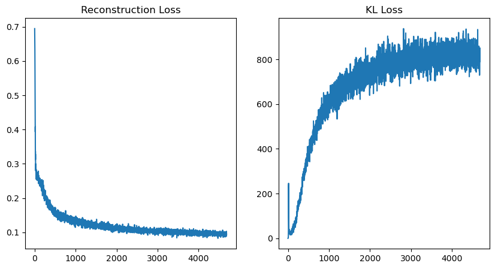

```python
# Prob1-5 VAE training loop
learning_rate = 1e-3
nz = 32
beta = 0

####################################### TODO #######################################
epochs = 5      # recommended 5-20 epochs
#################################### END TODO ######################################

# build VAE model
vae_model = VAE(nz, beta).to(device)
vae_model = vae_model.train()

# build optimizer and loss function
####################################### TODO #######################################
# Build the optimizer for the vae_model. We will again use the Adam optimizer with #
# the given learning rate and otherwise default parameters.                        #
####################################################################################
# same as AE
optimizer = torch.optim.Adam(vae_model.parameters(), lr=learning_rate)
#################################### END TODO ######################################

train_it = 0
rec_loss, kl_loss = [], []
print(f"Running {epochs} epochs with {beta=}")
for ep in range(epochs):
  print("Run Epoch {}".format(ep))
  ####################################### TODO #######################################
  # Implement the main training loop for the VAE model.                              #
  # HINT: Your training loop should sample batches from the data loader, run the     #
  #       forward pass of the VAE, compute the loss, perform the backward pass and   #
  #       perform one gradient step with the optimizer.                              #
  # HINT: Don't forget to erase old gradients before performing the backward pass.   #
  # HINT: This time we will use the loss() function of our model for computing the   #
  #       training loss. It outputs the total training loss and a dict containing    #
  #       the breakdown of reconstruction and KL loss.                               #
  ####################################################################################
  for data, _ in mnist_data_loader:
    data = data.to(device)
    data_flattened = data.view(data.size(0), -1)
    optimizer.zero_grad()
    outputs = vae_model(data_flattened)

    total_loss, losses = vae_model.loss(data, outputs)
    total_loss.backward()
    optimizer.step()

    rec_loss.append(losses['rec_loss']); kl_loss.append(losses['kl_loss'])
    if train_it % 100 == 0:
      print("It {}: Total Loss: {}, \t Rec Loss: {},\t KL Loss: {}"\
            .format(train_it, total_loss, losses['rec_loss'], losses['kl_loss']))
    train_it += 1
  #################################### END TODO ####################################

print("Done!")

rec_loss_plotdata = [foo.detach().cpu() for foo in rec_loss]
kl_loss_plotdata = [foo.detach().cpu() for foo in kl_loss]

# log the loss training curves
fig = plt.figure(figsize = (10, 5))
ax1 = plt.subplot(121)
ax1.plot(rec_loss_plotdata)
ax1.title.set_text("Reconstruction Loss")
ax2 = plt.subplot(122)
ax2.plot(kl_loss_plotdata)
ax2.title.set_text("KL Loss")
plt.show()
```

Let's look at some reconstructions and decoded embedding samples!

```
beta =  0
```

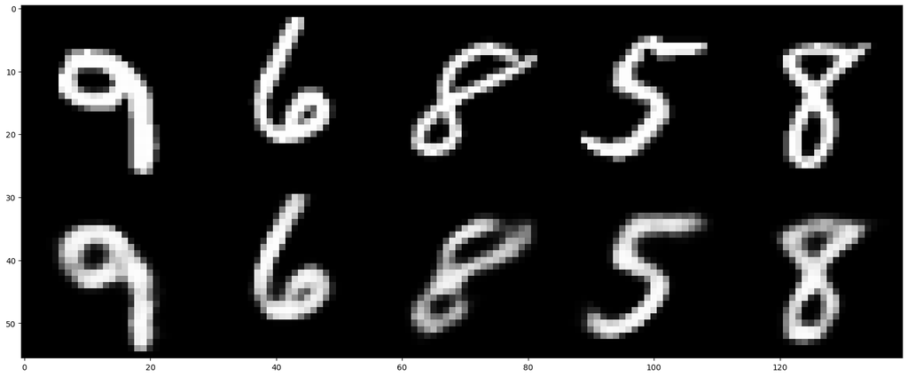

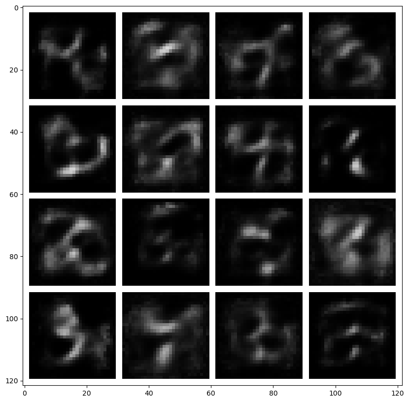

```python
# visualize VAE reconstructions and samples from the generative model
print("beta = ", beta)
vis_reconstruction(vae_model, randomize=True)
vis_samples(vae_model)
```

## Tweaking the loss function $\beta$ [2pt]

Prob1-6: Let's repeat the same experiment for $\beta = 10$, a very high value for the coefficient.

```
Running 5 epochs with beta=10
Run Epoch 0
It 0: Total Loss: 4.016552448272705, 	 Rec Loss: 0.6938815712928772,	 KL Loss: 0.3322671055793762
It 100: Total Loss: 0.2794148623943329, 	 Rec Loss: 0.2613603174686432,	 KL Loss: 0.0018054535612463951
It 200: Total Loss: 0.2788237929344177, 	 Rec Loss: 0.2714526057243347,	 KL Loss: 0.0007371199317276478
It 300: Total Loss: 0.27152860164642334, 	 Rec Loss: 0.26735422015190125,	 KL Loss: 0.0004174383357167244
It 400: Total Loss: 0.25725889205932617, 	 Rec Loss: 0.2547038793563843,	 KL Loss: 0.00025550229474902153
It 500: Total Loss: 0.27031391859054565, 	 Rec Loss: 0.268690288066864,	 KL Loss: 0.00016236165538430214
It 600: Total Loss: 0.26681870222091675, 	 Rec Loss: 0.2658362090587616,	 KL Loss: 9.824894368648529e-05
It 700: Total Loss: 0.2645943760871887, 	 Rec Loss: 0.26385298371315,	 KL Loss: 7.413839921355247e-05
It 800: Total Loss: 0.2501418888568878, 	 Rec Loss: 0.24961090087890625,	 KL Loss: 5.309935659170151e-05
It 900: Total Loss: 0.2736425995826721, 	 Rec Loss: 0.27322110533714294,	 KL Loss: 4.215072840452194e-05
Run Epoch 1
It 1000: Total Loss: 0.28142237663269043, 	 Rec Loss: 0.28108030557632446,	 KL Loss: 3.42060811817646e-05
It 1100: Total Loss: 0.2581726908683777, 	 Rec Loss: 0.2579230070114136,	 KL Loss: 2.4966895580291748e-05
It 1200: Total Loss: 0.2775796353816986, 	 Rec Loss: 0.27738139033317566,	 KL Loss: 1.9824597984552383e-05
It 1300: Total Loss: 0.26207688450813293, 	 Rec Loss: 0.2619163990020752,	 KL Loss: 1.604994758963585e-05
It 1400: Total Loss: 0.2571166753768921, 	 Rec Loss: 0.2569786310195923,	 KL Loss: 1.380452886223793e-05
It 1500: Total Loss: 0.2679003179073334, 	 Rec Loss: 0.26777297258377075,	 KL Loss: 1.2734439224004745e-05
It 1600: Total Loss: 0.2679794132709503, 	 Rec Loss: 0.26782143115997314,	 KL Loss: 1.5797559171915054e-05
It 1700: Total Loss: 0.270418643951416, 	 Rec Loss: 0.2703390121459961,	 KL Loss: 7.963273674249649e-06
It 1800: Total Loss: 0.2621978223323822, 	 Rec Loss: 0.26079779863357544,	 KL Loss: 0.00014000153169035912
Run Epoch 2
It 1900: Total Loss: 0.2662871778011322, 	 Rec Loss: 0.2662224769592285,	 KL Loss: 6.469897925853729e-06
It 2000: Total Loss: 0.26173555850982666, 	 Rec Loss: 0.26167458295822144,	 KL Loss: 6.097834557294846e-06
It 2100: Total Loss: 0.26119184494018555, 	 Rec Loss: 0.2611491084098816,	 KL Loss: 4.273373633623123e-06
It 2200: Total Loss: 0.2707250118255615, 	 Rec Loss: 0.27067500352859497,	 KL Loss: 5.000736564397812e-06
It 2300: Total Loss: 0.24756519496440887, 	 Rec Loss: 0.24752628803253174,	 KL Loss: 3.890134394168854e-06
It 2400: Total Loss: 0.2552410960197449, 	 Rec Loss: 0.2551194429397583,	 KL Loss: 1.2166332453489304e-05
It 2500: Total Loss: 0.2626834511756897, 	 Rec Loss: 0.26264166831970215,	 KL Loss: 4.178844392299652e-06
It 2600: Total Loss: 0.26178282499313354, 	 Rec Loss: 0.26175007224082947,	 KL Loss: 3.2763928174972534e-06
It 2700: Total Loss: 0.269582062959671, 	 Rec Loss: 0.2693401575088501,	 KL Loss: 2.4191103875637054e-05
It 2800: Total Loss: 0.26211151480674744, 	 Rec Loss: 0.26205021142959595,	 KL Loss: 6.129499524831772e-06
Run Epoch 3
It 2900: Total Loss: 0.25763383507728577, 	 Rec Loss: 0.2576010227203369,	 KL Loss: 3.281049430370331e-06
It 3000: Total Loss: 0.26332443952560425, 	 Rec Loss: 0.2633035182952881,	 KL Loss: 2.0936131477355957e-06
It 3100: Total Loss: 0.2630901634693146, 	 Rec Loss: 0.2630295753479004,	 KL Loss: 6.059650331735611e-06
It 3200: Total Loss: 0.26043981313705444, 	 Rec Loss: 0.26042142510414124,	 KL Loss: 1.8384307622909546e-06
It 3300: Total Loss: 0.26302477717399597, 	 Rec Loss: 0.26300352811813354,	 KL Loss: 2.1248124539852142e-06
It 3400: Total Loss: 0.275503545999527, 	 Rec Loss: 0.2754053771495819,	 KL Loss: 9.815674275159836e-06
It 3500: Total Loss: 0.2690805196762085, 	 Rec Loss: 0.2690189480781555,	 KL Loss: 6.158370524644852e-06
It 3600: Total Loss: 0.26635944843292236, 	 Rec Loss: 0.2663298547267914,	 KL Loss: 2.9583461582660675e-06
It 3700: Total Loss: 0.2718068063259125, 	 Rec Loss: 0.27175721526145935,	 KL Loss: 4.9578957259655e-06
Run Epoch 4
It 3800: Total Loss: 0.2491506189107895, 	 Rec Loss: 0.2490464746952057,	 KL Loss: 1.0414514690637589e-05
It 3900: Total Loss: 0.2648695409297943, 	 Rec Loss: 0.26483315229415894,	 KL Loss: 3.6386772990226746e-06
It 4000: Total Loss: 0.26311320066452026, 	 Rec Loss: 0.2630871832370758,	 KL Loss: 2.6011839509010315e-06
It 4100: Total Loss: 0.26228249073028564, 	 Rec Loss: 0.2622029781341553,	 KL Loss: 7.949769496917725e-06
It 4200: Total Loss: 0.26634666323661804, 	 Rec Loss: 0.2663046717643738,	 KL Loss: 4.197936505079269e-06
It 4300: Total Loss: 0.26979389786720276, 	 Rec Loss: 0.26973024010658264,	 KL Loss: 6.366986781358719e-06
It 4400: Total Loss: 0.2575802505016327, 	 Rec Loss: 0.25755658745765686,	 KL Loss: 2.3650936782360077e-06
It 4500: Total Loss: 0.25071004033088684, 	 Rec Loss: 0.2506535053253174,	 KL Loss: 5.65405935049057e-06
It 4600: Total Loss: 0.26633602380752563, 	 Rec Loss: 0.26632195711135864,	 KL Loss: 1.4076940715312958e-06
Done!
```

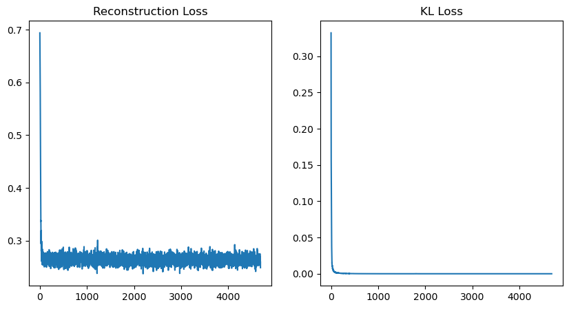

```python
# VAE training loop
learning_rate = 1e-3
nz = 32
beta = 10

####################################### TODO #######################################
epochs = 5      # recommended 5-20 epochs
#################################### END TODO ######################################

# build VAE model
vae_model = VAE(nz, beta).to(device)
vae_model = vae_model.train()

# build optimizer and loss function
####################################### TODO #######################################
# Build the optimizer for the vae_model. We will again use the Adam optimizer with #
# the given learning rate and otherwise default parameters.                        #
####################################################################################
# same as AE
optimizer = torch.optim.Adam(vae_model.parameters(), lr=learning_rate)
#################################### END TODO ######################################

train_it = 0
rec_loss, kl_loss = [], []
print(f"Running {epochs} epochs with {beta=}")
for ep in range(epochs):
  print("Run Epoch {}".format(ep))
  ####################################### TODO #######################################
  # Implement the main training loop for the VAE model.                              #
  # HINT: Your training loop should sample batches from the data loader, run the     #
  #       forward pass of the VAE, compute the loss, perform the backward pass and   #
  #       perform one gradient step with the optimizer.                              #
  # HINT: Don't forget to erase old gradients before performing the backward pass.   #
  # HINT: This time we will use the loss() function of our model for computing the   #
  #       training loss. It outputs the total training loss and a dict containing    #
  #       the breakdown of reconstruction and KL loss.                               #
  ####################################################################################
  for data, _ in mnist_data_loader:
    data = data.to(device)
    data_flattened = data.view(data.size(0), -1)
    optimizer.zero_grad()
    outputs = vae_model(data_flattened)

    total_loss, losses = vae_model.loss(data, outputs)
    total_loss.backward()
    optimizer.step()

    rec_loss.append(losses['rec_loss']); kl_loss.append(losses['kl_loss'])
    if train_it % 100 == 0:
      print("It {}: Total Loss: {}, \t Rec Loss: {},\t KL Loss: {}"\
            .format(train_it, total_loss, losses['rec_loss'], losses['kl_loss']))
    train_it += 1
  #################################### END TODO ####################################

print("Done!")

rec_loss_plotdata = [foo.detach().cpu() for foo in rec_loss]
kl_loss_plotdata = [foo.detach().cpu() for foo in kl_loss]

# log the loss training curves
fig = plt.figure(figsize = (10, 5))
ax1 = plt.subplot(121)
ax1.plot(rec_loss_plotdata)
ax1.title.set_text("Reconstruction Loss")
ax2 = plt.subplot(122)
ax2.plot(kl_loss_plotdata)
ax2.title.set_text("KL Loss")
plt.show()
```

> **Inline Question: What can you observe when setting $\beta = 0$ and $\beta = 10$? Explain your observations! [2pt]** (max 200 words)

## Obtaining the best $\beta$-factor [5pt]

Prob 1-6 continued: Now we can start tuning the beta value to achieve a good result. First describe what a "good result" would look like (focus what you would expect for reconstructions and sample quality).

> **Inline Question: Characterize what properties you would expect for reconstructions and samples of a well-tuned VAE! [3pt]** (max 200 words)

> **Answer**: Some properties I expected was images that weren't blurry/static. If the images generated became digits, then I would try to make the digits as clear as possible, similar to the digits that the model was trained on. On the Loss side, I looked mainly at the KL loss, and tried to see when the loss converges. With the hint below, I've tried 2, 1, 0.1, 0.01, 0.001, 0.0001, and 0.00001. I've noticed that everything was blurry when below 0.01 and things became a bit clearer above 0.001, so I've used 0.005. Everything above 5 looked static and the KL Loss fell to the floor similar to when Beta=10.

Now that you know what outcome we would like to obtain, try to tune $\beta$ to achieve this result. Logarithmic search in steps of 10x will be helpful, good results can be achieved after ~20 epochs of training. Training reconstructions should be high quality, test samples should be diverse, distinguishable numbers, most samples recognizable as numbers.

**Answer: Tuned beta value **_0.005__** [2pt]**

```
Running 5 epochs with beta=0.005
Run Epoch 0
It 0: Total Loss: 0.695447564125061, 	 Rec Loss: 0.6942054629325867,	 KL Loss: 0.24842076003551483
It 100: Total Loss: 0.26221510767936707, 	 Rec Loss: 0.25939327478408813,	 KL Loss: 0.564367949962616
It 200: Total Loss: 0.25910136103630066, 	 Rec Loss: 0.2530350983142853,	 KL Loss: 1.2132530212402344
It 300: Total Loss: 0.2622299790382385, 	 Rec Loss: 0.2549610137939453,	 KL Loss: 1.4537911415100098
It 400: Total Loss: 0.2482222318649292, 	 Rec Loss: 0.23902639746665955,	 KL Loss: 1.8391658067703247
It 500: Total Loss: 0.23586837947368622, 	 Rec Loss: 0.2271619588136673,	 KL Loss: 1.7412853240966797
It 600: Total Loss: 0.25628596544265747, 	 Rec Loss: 0.24306169152259827,	 KL Loss: 2.644852638244629
It 700: Total Loss: 0.23451991379261017, 	 Rec Loss: 0.21719755232334137,	 KL Loss: 3.4644715785980225
It 800: Total Loss: 0.23235957324504852, 	 Rec Loss: 0.21382898092269897,	 KL Loss: 3.70611834526062
It 900: Total Loss: 0.21575406193733215, 	 Rec Loss: 0.19605572521686554,	 KL Loss: 3.9396681785583496
Run Epoch 1
It 1000: Total Loss: 0.21582791209220886, 	 Rec Loss: 0.195790097117424,	 KL Loss: 4.007562637329102
It 1100: Total Loss: 0.22375386953353882, 	 Rec Loss: 0.20255297422409058,	 KL Loss: 4.240177631378174
It 1200: Total Loss: 0.2106122076511383, 	 Rec Loss: 0.18889127671718597,	 KL Loss: 4.344187259674072
It 1300: Total Loss: 0.22004187107086182, 	 Rec Loss: 0.19680392742156982,	 KL Loss: 4.647588729858398
It 1400: Total Loss: 0.21626143157482147, 	 Rec Loss: 0.19062918424606323,	 KL Loss: 5.126448631286621
It 1500: Total Loss: 0.2159644216299057, 	 Rec Loss: 0.19014032185077667,	 KL Loss: 5.164820671081543
It 1600: Total Loss: 0.21685956418514252, 	 Rec Loss: 0.18842779099941254,	 KL Loss: 5.686354160308838
It 1700: Total Loss: 0.2109513133764267, 	 Rec Loss: 0.18161404132843018,	 KL Loss: 5.86745548248291
It 1800: Total Loss: 0.20724926888942719, 	 Rec Loss: 0.1773328334093094,	 KL Loss: 5.983288288116455
Run Epoch 2
It 1900: Total Loss: 0.20504504442214966, 	 Rec Loss: 0.17669522762298584,	 KL Loss: 5.66996431350708
It 2000: Total Loss: 0.21955475211143494, 	 Rec Loss: 0.18938857316970825,	 KL Loss: 6.033236980438232
It 2100: Total Loss: 0.2097070813179016, 	 Rec Loss: 0.17786656320095062,	 KL Loss: 6.368104934692383
It 2200: Total Loss: 0.20045205950737, 	 Rec Loss: 0.16977034509181976,	 KL Loss: 6.1363444328308105
It 2300: Total Loss: 0.19537541270256042, 	 Rec Loss: 0.1620456874370575,	 KL Loss: 6.6659440994262695
It 2400: Total Loss: 0.20608729124069214, 	 Rec Loss: 0.17335855960845947,	 KL Loss: 6.545748233795166
It 2500: Total Loss: 0.20578333735466003, 	 Rec Loss: 0.17491042613983154,	 KL Loss: 6.174583911895752
It 2600: Total Loss: 0.19697165489196777, 	 Rec Loss: 0.16659413278102875,	 KL Loss: 6.075504779815674
It 2700: Total Loss: 0.2024015635251999, 	 Rec Loss: 0.17179839313030243,	 KL Loss: 6.120635509490967
It 2800: Total Loss: 0.19320783019065857, 	 Rec Loss: 0.15996690094470978,	 KL Loss: 6.648186683654785
Run Epoch 3
It 2900: Total Loss: 0.1926327645778656, 	 Rec Loss: 0.15964587032794952,	 KL Loss: 6.597377777099609
It 3000: Total Loss: 0.1983056366443634, 	 Rec Loss: 0.16701722145080566,	 KL Loss: 6.257682800292969
It 3100: Total Loss: 0.2086985558271408, 	 Rec Loss: 0.17633776366710663,	 KL Loss: 6.472158432006836
It 3200: Total Loss: 0.2072116583585739, 	 Rec Loss: 0.17279617488384247,	 KL Loss: 6.8830976486206055
It 3300: Total Loss: 0.20518779754638672, 	 Rec Loss: 0.17261385917663574,	 KL Loss: 6.51478910446167
It 3400: Total Loss: 0.20083723962306976, 	 Rec Loss: 0.1681748777627945,	 KL Loss: 6.532472133636475
It 3500: Total Loss: 0.197123721241951, 	 Rec Loss: 0.1649039089679718,	 KL Loss: 6.443962097167969
It 3600: Total Loss: 0.19646210968494415, 	 Rec Loss: 0.16219240427017212,	 KL Loss: 6.853941440582275
It 3700: Total Loss: 0.19333946704864502, 	 Rec Loss: 0.15813693404197693,	 KL Loss: 7.040506362915039
Run Epoch 4
It 3800: Total Loss: 0.1905646175146103, 	 Rec Loss: 0.15618668496608734,	 KL Loss: 6.875585556030273
It 3900: Total Loss: 0.20256803929805756, 	 Rec Loss: 0.16646422445774078,	 KL Loss: 7.220763206481934
It 4000: Total Loss: 0.19253891706466675, 	 Rec Loss: 0.1567854881286621,	 KL Loss: 7.150684356689453
It 4100: Total Loss: 0.19676423072814941, 	 Rec Loss: 0.16406391561031342,	 KL Loss: 6.540061950683594
It 4200: Total Loss: 0.19047005474567413, 	 Rec Loss: 0.1564657986164093,	 KL Loss: 6.800852298736572
It 4300: Total Loss: 0.19490942358970642, 	 Rec Loss: 0.15882687270641327,	 KL Loss: 7.21651029586792
It 4400: Total Loss: 0.20695170760154724, 	 Rec Loss: 0.1677381992340088,	 KL Loss: 7.842700958251953
It 4500: Total Loss: 0.19110475480556488, 	 Rec Loss: 0.1546599119901657,	 KL Loss: 7.288968563079834
It 4600: Total Loss: 0.19248023629188538, 	 Rec Loss: 0.1560642123222351,	 KL Loss: 7.283204555511475
Done!
```

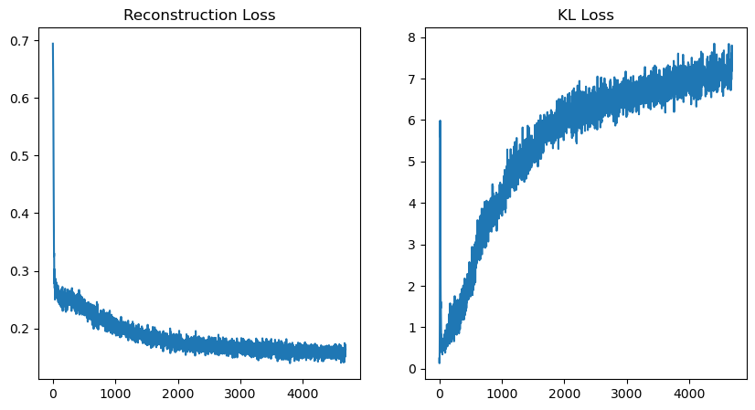

```python
# Tuning for best beta
learning_rate = 1e-3
nz = 32

####################################### TODO #######################################
epochs = 5      # recommended 5-20 epochs
beta = 0.005 # Tune this for best results
#################################### END TODO ######################################

# build VAE model
vae_model = VAE(nz, beta).to(device)    # transfer model to GPU if available
vae_model = vae_model.train()   # set model in train mode (eg batchnorm params get updated)

# build optimizer and loss function
####################################### TODO #######################################
# Build the optimizer for the vae_model. We will again use the Adam optimizer with #
# the given learning rate and otherwise default parameters.                        #
####################################################################################
# same as AE
optimizer = torch.optim.Adam(vae_model.parameters(), lr=learning_rate)
#################################### END TODO ######################################

train_it = 0
rec_loss, kl_loss = [], []
print(f"Running {epochs} epochs with {beta=}")
for ep in range(epochs):
  print("Run Epoch {}".format(ep))
  ####################################### TODO #######################################
  # Implement the main training loop for the VAE model.                              #
  # HINT: Your training loop should sample batches from the data loader, run the     #
  #       forward pass of the VAE, compute the loss, perform the backward pass and   #
  #       perform one gradient step with the optimizer.                              #
  # HINT: Don't forget to erase old gradients before performing the backward pass.   #
  # HINT: This time we will use the loss() function of our model for computing the   #
  #       training loss. It outputs the total training loss and a dict containing    #
  #       the breakdown of reconstruction and KL loss.                               #
  ####################################################################################
  for data, _ in mnist_data_loader:
    data = data.to(device)
    data_flattened = data.view(data.size(0), -1)
    # print(data_flattened.shape)
    optimizer.zero_grad()
    outputs = vae_model(data_flattened)

    total_loss, losses = vae_model.loss(data, outputs)
    total_loss.backward()
    optimizer.step()

    rec_loss.append(losses['rec_loss']); kl_loss.append(losses['kl_loss'])
    if train_it % 100 == 0:
      print("It {}: Total Loss: {}, \t Rec Loss: {},\t KL Loss: {}"\
            .format(train_it, total_loss, losses['rec_loss'], losses['kl_loss']))
    train_it += 1
  #################################### END TODO ####################################

print("Done!")

rec_loss_plotdata = [foo.detach().cpu() for foo in rec_loss]
kl_loss_plotdata = [foo.detach().cpu() for foo in kl_loss]

# log the loss training curves
fig = plt.figure(figsize = (10, 5))
ax1 = plt.subplot(121)
ax1.plot(rec_loss_plotdata)
ax1.title.set_text("Reconstruction Loss")
ax2 = plt.subplot(122)
ax2.plot(kl_loss_plotdata)
ax2.title.set_text("KL Loss")
plt.show()
```

Let's look at some reconstructions and decoded embedding samples for this beta!

```
BEST beta =  0.005
```

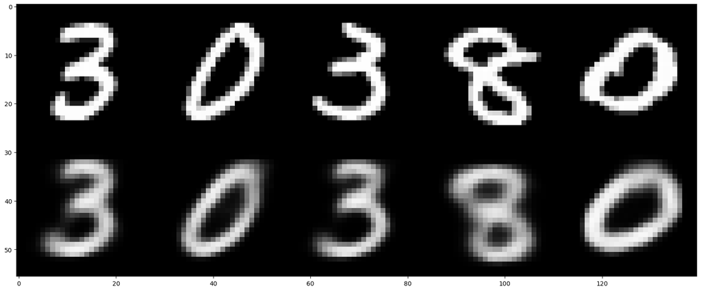

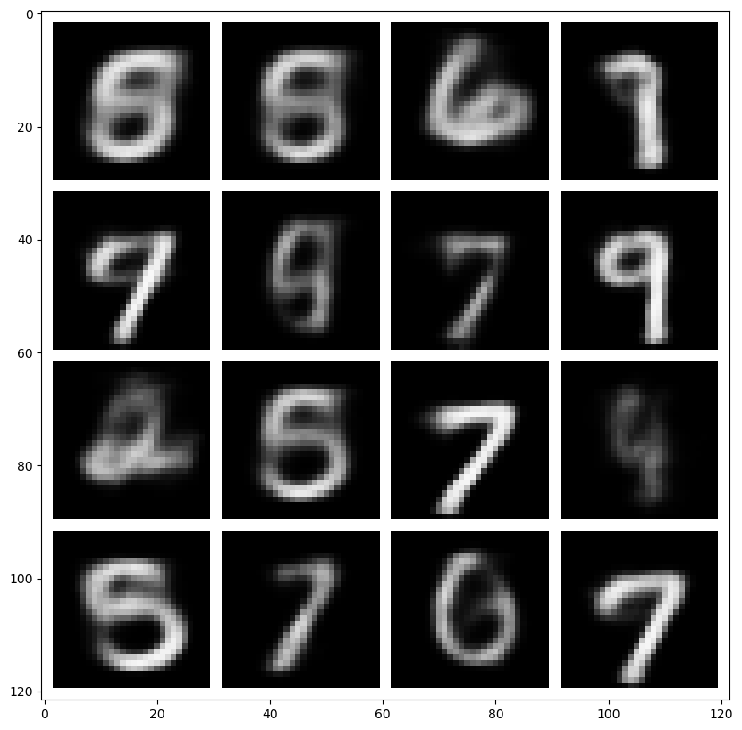

```python
# [OPTIONAL] visualize VAE reconstructions and samples from the generative model
print("BEST beta = ", beta)
vis_reconstruction(vae_model, randomize=True)
vis_samples(vae_model)
```

# 4. Embedding Space Interpolation [3pt]

As mentioned in the introduction, AEs and VAEs cannot only be used to generate images, but also to learn low-dimensional representations of their inputs. In this final section we will investigate the representations we learned with both models by **interpolating in embedding space** between different images. We will encode two images into their low-dimensional embedding representations, then interpolate these embeddings and reconstruct the result.

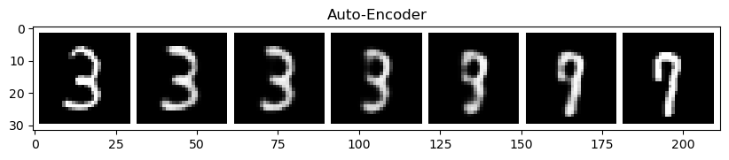

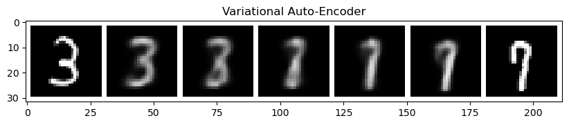

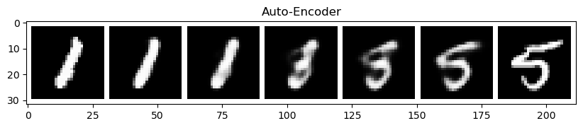

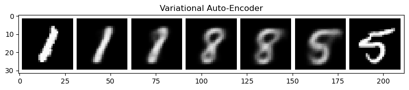

```python
# Prob1-7
nz=32

def get_image_with_label(target_label):
  """Returns a random image from the training set with the requested digit."""
  for img_batch, label_batch in mnist_data_loader:
    for img, label in zip(img_batch, label_batch):
      if label == target_label:
        return img.to(device)

def interpolate_and_visualize(model, tag, start_img, end_img):
  """Encodes images and performs interpolation. Displays decodings."""
  model.eval()    # put model in eval mode to avoid updating batchnorm

  # encode both images into embeddings (use posterior mean for interpolation)
  z_start = model.encoder(start_img[None].reshape(1,784))[..., :nz]
  z_end = model.encoder(end_img[None].reshape(1,784))[..., :nz]

  # compute interpolated latents
  N_INTER_STEPS = 5
  z_inter = [z_start + i/N_INTER_STEPS * (z_end - z_start) for i in range(N_INTER_STEPS)]

  # decode interpolated embeddings (as a single batch)
  img_inter = model.decoder(torch.cat(z_inter))
  img_inter = img_inter.reshape(-1, 28, 28)

  # reshape result and display interpolation
  vis_imgs = torch.cat([start_img, img_inter, end_img]).reshape(-1,1,28,28)
  fig = plt.figure(figsize = (10, 10))
  ax1 = plt.subplot(111)
  ax1.imshow(torchvision.utils.make_grid(vis_imgs, nrow=N_INTER_STEPS+2, pad_value=1.)\
                  .data.cpu().numpy().transpose(1, 2, 0), cmap='gray')
  plt.title(tag)
  plt.show()


### Interpolation 1
START_LABEL  = 3  # ... TODO CHOOSE
END_LABEL = 7 # ... TODO CHOOSE
# sample two training images with given labels
start_img = get_image_with_label(START_LABEL)
end_img = get_image_with_label(END_LABEL)
# visualize interpolations for AE and VAE models
interpolate_and_visualize(ae_model, "Auto-Encoder", start_img, end_img)
interpolate_and_visualize(vae_model, "Variational Auto-Encoder", start_img, end_img)

### Interpolation 2
START_LABEL = 1 # ... TODO CHOOSE
END_LABEL = 5 # ... TODO CHOOSE
# sample two training images with given labels
start_img = get_image_with_label(START_LABEL)
end_img = get_image_with_label(END_LABEL)
# visualize interpolations for AE and VAE models
interpolate_and_visualize(ae_model, "Auto-Encoder", start_img, end_img)
interpolate_and_visualize(vae_model, "Variational Auto-Encoder", start_img, end_img)
```

Repeat the experiment for different start / end labels and different samples. Describe your observations.

> **Prob1-7 continued: Inline Question: Repeat the interpolation experiment with different start / end labels and multiple samples. Describe your observations! [2 pt]**
> 1. How do AE and VAE embedding space interpolations differ?
> 2. How do you expect these differences to affect the usefulness of the learned representation for downstream learning? (max 300 words)

> **Answer**:
> 1. VAE interpolation is smoother than AE. This is evident when transitioning from 1 - 5. Sometimes, AE has a line that connects the top point of 5 to the bottom point of 5. On the other hand, VAE doesn't create the line when shifting 1 to 5, resulting in better interpolation. In all, VAE has a more continuous smoother edges compared to AE.
> 2. The interpolation means that VAE learned a better representation compared to AE. This means when we feed the reperesentation for downstream learning, the other model with the better learned representation can perform better as it will have a more reliable representation.

# 5. Conditional VAE

Let us now try a Conditional VAE Now we will try to create a [Conditional VAE](https://proceedings.neurips.cc/paper/2014/file/d523773c6b194f37b938d340d5d02232-Paper.pdf), where we can condition the encoder and decoder of the VAE on the label `c`.

## Defining the conditional Encoder, Decoder, and VAE models [5 pt]

Prob1-8. We create a separate encoder and decoder class that take in an additional argument `c` in their forward pass, and then build our CVAE model on top of it. Note that the encoder and decoder just need to append `c` to the standard inputs to these modules.

```python
def idx2onehot(idx, n):
    """Converts a batch of indices to a one-hot representation."""
    assert torch.max(idx).item() < n
    if idx.dim() == 1:
        idx = idx.unsqueeze(1)
    onehot = torch.zeros(idx.size(0), n).to(idx.device)
    onehot.scatter_(1, idx, 1)

    return onehot

# Let's define encoder and decoder networks

class CVAEEncoder(nn.Module):
  def __init__(self, nz, input_size, conditional, num_labels):
    super().__init__()
    self.input_size = input_size + num_labels if conditional else input_size
    self.num_labels = num_labels
    self.conditional = conditional

    ################################# TODO #########################################
    # Create the network architecture using a nn.Sequential module wrapper.        #
    # Encoder Architecture:                                                        #
    # - input_size -> 256                                                          #
    # - ReLU                                                                       #
    # - 256 -> 64                                                                  #
    # - ReLU                                                                       #
    # - 64 -> nz                                                                   #
    # HINT: Verify the shapes of intermediate layers by running partial networks   #
    #        (with the next notebook cell) and visualizing the output shapes.      #
    ################################################################################
    self.net = nn.Sequential(
        nn.Linear(self.input_size, 256),
        nn.ReLU(),
        nn.Linear(256, 64),
        nn.ReLU(),
        nn.Linear(64, nz)
    )
    ################################ END TODO ######################################

  def forward(self, x, c=None):
    ################################# TODO #########################################
    # If using conditional VAE, concatenate x and a onehot version of c to create  #
    # the full input. Use function idx2onehot above.                               #
    ################################################################################
    if self.conditional:
        c_onehot = idx2onehot(c, self.num_labels)
        x = torch.cat([x, c_onehot], dim=-1)
    ################################################################################
    return self.net(x)


class CVAEDecoder(nn.Module):
  def __init__(self, nz, output_size, conditional, num_labels):
    super().__init__()
    self.output_size = output_size
    self.conditional = conditional
    self.num_labels = num_labels
    if self.conditional:
        nz = nz + num_labels
    ################################# TODO #########################################
    # Create the network architecture using a nn.Sequential module wrapper.        #
    # Decoder Architecture (mirrors encoder architecture):                         #
    # - nz -> 64                                                                   #
    # - ReLU                                                                       #
    # - 64 -> 256                                                                  #
    # - ReLU                                                                       #
    # - 256 -> output_size                                                         #
    ################################################################################
    self.net = nn.Sequential(
        nn.Linear(nz, 64),
        nn.ReLU(),
        nn.Linear(64, 256),
        nn.ReLU(),
        nn.Linear(256, output_size),
        nn.Sigmoid()
    )
    ################################ END TODO #######################################

  def forward(self, z, c=None):
    ################################# TODO #########################################
    # If using conditional VAE, concatenate z and a onehot version of c to create  #
    # the full embedding. Use function idx2onehot above.                           #
    ################################################################################
    if self.conditional:
        c_onehot = idx2onehot(c, self.num_labels)
        z = torch.cat([z, c_onehot], dim=-1)
    ################################ END TODO #######################################
    return self.net(z).reshape(-1, 1, self.output_size)


class CVAE(nn.Module):
    def __init__(self, nz, beta=1.0, conditional=False, num_labels=0):
        super().__init__()
        if conditional:
            assert num_labels > 0
        self.beta = beta
        self.encoder = CVAEEncoder(2*nz, input_size=in_size, conditional=conditional, num_labels=num_labels)
        self.decoder = CVAEDecoder(nz, output_size=out_size, conditional=conditional, num_labels=num_labels)

    def forward(self, x, c=None):
        if x.dim() > 2:
            x = x.view(-1, 28*28)

        q = self.encoder(x,c)
        mu, log_sigma = torch.chunk(q, 2, dim=-1)

        eps = torch.normal(mean=torch.zeros_like(mu), std=torch.ones_like(log_sigma))
        # eps = torch.randn_like(mu) # Alternatively use this
        z = mu + eps * torch.exp(log_sigma)

        reconstruction = self.decoder(z, c)

        return {'q': q, 'rec': reconstruction, 'c': c}

    def loss(self, x, outputs):
        ####################################### TODO #######################################
        # Implement the loss computation of the VAE.                                       #
        # HINT: Your code should implement the following steps:                            #
        #          1. compute the image reconstruction loss, similar to AE loss above      #
        #          2. compute the KL divergence loss between the inferred posterior        #
        #             distribution and a unit Gaussian prior; you can use the provided     #
        #             function above for computing the KL divergence between two Gaussians #
        #             parametrized by mean and log_sigma                                   #
        # HINT: Make sure to compute the KL divergence in the correct order since it is    #
        #       not symmetric!!  ie. KL(p, q) != KL(q, p)                                  #
        ####################################################################################
        if x.dim() > 2:
          x = x.view(-1, 28*28)

        rec = outputs['rec']
        if rec.dim() > 2:
          rec = rec.view(-1, 28*28)

        rec_loss = torch.nn.functional.mse_loss(rec, x, reduction='sum') / x.size(0)
        # rec_loss = torch.nn.functional.mse_loss(outputs['rec'], x, reduction='sum') / x.size(0)

        mu, log_sigma = torch.chunk(outputs['q'], 2, dim=-1)
        kl_loss = -0.5 * torch.sum(1 + log_sigma - mu.pow(2) - log_sigma.exp()) / x.size(0)
        #################################### END TODO ######################################

        # return weighted objective
        return rec_loss + self.beta * kl_loss, \
            {'rec_loss': rec_loss, 'kl_loss': kl_loss}

    def reconstruct(self, x, c=None):
        """Use mean of posterior estimate for visualization reconstruction."""
        ####################################### TODO #######################################
        # This function is used for visualizing reconstructions of our VAE model. To       #
        # obtain the maximum likelihood estimate we bypass the sampling procedure of the   #
        # inferred latent and instead directly use the mean of the inferred posterior.     #
        # HINT: encode the input image and then decode the mean of the posterior to obtain #
        #       the reconstruction.                                                        #
        ####################################################################################
        if x.dim() > 2:
            x = x.view(-1, 28 * 28)

        q = self.encoder(x, c)
        mu, log_sigma = torch.chunk(q, 2, dim=-1)
        image = self.decoder(mu, c)
        #################################### END TODO ######################################
        return image
```

## Setting up the CVAE Training loop

```
Running 7 epochs with beta=1.5
Run Epoch 0
It 0: Total Loss: 182.8697967529297, 	 Rec Loss: 182.64010620117188,	 KL Loss: 0.1531224101781845
It 100: Total Loss: 51.97646713256836, 	 Rec Loss: 51.59844207763672,	 KL Loss: 0.2520160973072052
It 200: Total Loss: 52.17173385620117, 	 Rec Loss: 50.459388732910156,	 KL Loss: 1.1415637731552124
It 300: Total Loss: 44.64760208129883, 	 Rec Loss: 42.6434211730957,	 KL Loss: 1.3361197710037231
It 400: Total Loss: 41.85912322998047, 	 Rec Loss: 39.43207550048828,	 KL Loss: 1.6180315017700195
It 500: Total Loss: 42.277374267578125, 	 Rec Loss: 39.358680725097656,	 KL Loss: 1.9457955360412598
It 600: Total Loss: 37.5777702331543, 	 Rec Loss: 34.58966064453125,	 KL Loss: 1.9920729398727417
It 700: Total Loss: 40.65373229980469, 	 Rec Loss: 36.70097351074219,	 KL Loss: 2.635171890258789
It 800: Total Loss: 36.392391204833984, 	 Rec Loss: 32.508583068847656,	 KL Loss: 2.5892043113708496
It 900: Total Loss: 34.71350860595703, 	 Rec Loss: 30.487092971801758,	 KL Loss: 2.8176109790802
Run Epoch 1
It 1000: Total Loss: 35.377479553222656, 	 Rec Loss: 31.307941436767578,	 KL Loss: 2.7130250930786133
It 1100: Total Loss: 34.82865524291992, 	 Rec Loss: 30.26798439025879,	 KL Loss: 3.0404465198516846
It 1200: Total Loss: 33.141807556152344, 	 Rec Loss: 28.869670867919922,	 KL Loss: 2.8480899333953857
It 1300: Total Loss: 30.79829978942871, 	 Rec Loss: 26.44118881225586,	 KL Loss: 2.904740571975708
It 1400: Total Loss: 31.710506439208984, 	 Rec Loss: 26.909168243408203,	 KL Loss: 3.200892925262451
It 1500: Total Loss: 30.408973693847656, 	 Rec Loss: 25.817834854125977,	 KL Loss: 3.0607588291168213
It 1600: Total Loss: 31.773292541503906, 	 Rec Loss: 27.226722717285156,	 KL Loss: 3.031045913696289
It 1700: Total Loss: 31.534164428710938, 	 Rec Loss: 26.64791488647461,	 KL Loss: 3.2574996948242188
It 1800: Total Loss: 29.93463897705078, 	 Rec Loss: 25.39954948425293,	 KL Loss: 3.02339243888855
Run Epoch 2
It 1900: Total Loss: 28.244140625, 	 Rec Loss: 23.279293060302734,	 KL Loss: 3.3098976612091064
It 2000: Total Loss: 27.142738342285156, 	 Rec Loss: 22.574268341064453,	 KL Loss: 3.045646905899048
It 2100: Total Loss: 28.861064910888672, 	 Rec Loss: 23.920812606811523,	 KL Loss: 3.2935023307800293
It 2200: Total Loss: 30.206035614013672, 	 Rec Loss: 25.241836547851562,	 KL Loss: 3.3094658851623535
It 2300: Total Loss: 30.530237197875977, 	 Rec Loss: 25.488285064697266,	 KL Loss: 3.3613014221191406
It 2400: Total Loss: 30.87923812866211, 	 Rec Loss: 26.084857940673828,	 KL Loss: 3.1962528228759766
It 2500: Total Loss: 28.528091430664062, 	 Rec Loss: 23.376840591430664,	 KL Loss: 3.43416690826416
It 2600: Total Loss: 29.71570587158203, 	 Rec Loss: 24.43114471435547,	 KL Loss: 3.523041248321533
It 2700: Total Loss: 29.20309066772461, 	 Rec Loss: 24.1287784576416,	 KL Loss: 3.3828752040863037
It 2800: Total Loss: 29.013736724853516, 	 Rec Loss: 23.899085998535156,	 KL Loss: 3.4097671508789062
Run Epoch 3
It 2900: Total Loss: 29.403026580810547, 	 Rec Loss: 24.253814697265625,	 KL Loss: 3.4328081607818604
It 3000: Total Loss: 27.02022933959961, 	 Rec Loss: 21.752098083496094,	 KL Loss: 3.5120880603790283
It 3100: Total Loss: 26.7257137298584, 	 Rec Loss: 21.545486450195312,	 KL Loss: 3.4534850120544434
It 3200: Total Loss: 28.484439849853516, 	 Rec Loss: 23.087818145751953,	 KL Loss: 3.597747802734375
It 3300: Total Loss: 27.983684539794922, 	 Rec Loss: 22.475582122802734,	 KL Loss: 3.6720690727233887
It 3400: Total Loss: 28.062564849853516, 	 Rec Loss: 22.738876342773438,	 KL Loss: 3.5491249561309814
```

[output cut: 20 more lines]

```
It 5300: Total Loss: 24.932342529296875, 	 Rec Loss: 19.200435638427734,	 KL Loss: 3.8212714195251465
It 5400: Total Loss: 25.816137313842773, 	 Rec Loss: 20.06198501586914,	 KL Loss: 3.836101531982422
It 5500: Total Loss: 25.95771026611328, 	 Rec Loss: 20.13488006591797,	 KL Loss: 3.8818862438201904
It 5600: Total Loss: 24.244140625, 	 Rec Loss: 18.53177261352539,	 KL Loss: 3.8082454204559326
Run Epoch 6
It 5700: Total Loss: 23.95183563232422, 	 Rec Loss: 17.828174591064453,	 KL Loss: 4.08243989944458
It 5800: Total Loss: 25.094802856445312, 	 Rec Loss: 19.298131942749023,	 KL Loss: 3.8644471168518066
It 5900: Total Loss: 24.77018928527832, 	 Rec Loss: 18.973249435424805,	 KL Loss: 3.86462664604187
It 6000: Total Loss: 25.373550415039062, 	 Rec Loss: 19.534475326538086,	 KL Loss: 3.892716884613037
It 6100: Total Loss: 23.744369506835938, 	 Rec Loss: 17.858795166015625,	 KL Loss: 3.923715591430664
It 6200: Total Loss: 26.431943893432617, 	 Rec Loss: 20.316287994384766,	 KL Loss: 4.077104091644287
It 6300: Total Loss: 24.533037185668945, 	 Rec Loss: 18.57902717590332,	 KL Loss: 3.969339609146118
It 6400: Total Loss: 25.08934211730957, 	 Rec Loss: 19.043821334838867,	 KL Loss: 4.030346870422363
It 6500: Total Loss: 24.62295913696289, 	 Rec Loss: 18.63275146484375,	 KL Loss: 3.99347186088562
Done!
```

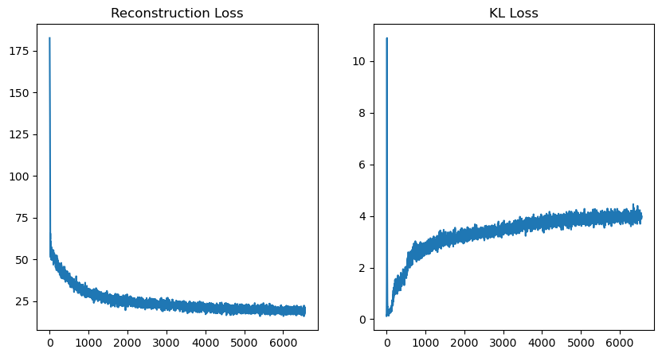

```python
learning_rate = 1e-3
nz = 32

####################################### TODO #######################################
# Tune the beta parameter to obtain good training results. However, for the    #
# initial experiments leave beta = 0 in order to verify our implementation.        #
####################################################################################
epochs = 7 # works with fewer epochs than AE, VAE. we only test conditional samples.
beta = 1.5
#################################### END TODO ######################################

# build CVAE model
conditional = True
cvae_model = CVAE(nz, beta, conditional=conditional, num_labels=10).to(device)    # transfer model to GPU if available
cvae_model = cvae_model.train()   # set model in train mode (eg batchnorm params get updated)

# build optimizer and loss function
####################################### TODO #######################################
# Build the optimizer for the cvae_model. We will again use the Adam optimizer with #
# the given learning rate and otherwise default parameters.                        #
####################################################################################
# same as AE
optimizer = torch.optim.Adam(cvae_model.parameters(), lr=learning_rate)
#################################### END TODO ######################################

train_it = 0
rec_loss, kl_loss = [], []
print(f"Running {epochs} epochs with {beta=}")
for ep in range(epochs):
  print(f"Run Epoch {ep}")
  ####################################### TODO #######################################
  # Implement the main training loop for the model.                                  #
  # If using conditional VAE, remember to pass the conditional variable c to the     #
  # forward pass                                                                     #
  # HINT: Your training loop should sample batches from the data loader, run the     #
  #       forward pass of the model, compute the loss, perform the backward pass and #
  #       perform one gradient step with the optimizer.                              #
  # HINT: Don't forget to erase old gradients before performing the backward pass.   #
  # HINT: As before, we will use the loss() function of our model for computing the  #
  #       training loss. It outputs the total training loss and a dict containing    #
  #       the breakdown of reconstruction and KL loss.                               #
  ####################################################################################
  for data, labels in mnist_data_loader:
    data, labels = data.to(device), labels.to(device)
    data_flattened = data.view(data.size(0), -1)

    optimizer.zero_grad()
    outputs = cvae_model(data_flattened, c=labels)

    total_loss, losses = cvae_model.loss(data, outputs)
    total_loss.backward()
    optimizer.step()

    rec_loss.append(losses['rec_loss']); kl_loss.append(losses['kl_loss'])
    if train_it % 100 == 0:
      print("It {}: Total Loss: {}, \t Rec Loss: {},\t KL Loss: {}"\
            .format(train_it, total_loss, losses['rec_loss'], losses['kl_loss']))
    train_it += 1
  #################################### END TODO ####################################

print("Done!")

rec_loss_plotdata = [foo.detach().cpu() for foo in rec_loss]
kl_loss_plotdata = [foo.detach().cpu() for foo in kl_loss]

# log the loss training curves
fig = plt.figure(figsize = (10, 5))
ax1 = plt.subplot(121)
ax1.plot(rec_loss_plotdata)
ax1.title.set_text("Reconstruction Loss")
ax2 = plt.subplot(122)
ax2.plot(kl_loss_plotdata)
ax2.title.set_text("KL Loss")
plt.show()
```

### Verifying conditional samples from CVAE [6 pt]

Now let us generate samples from the trained model, conditioned on all the labels.

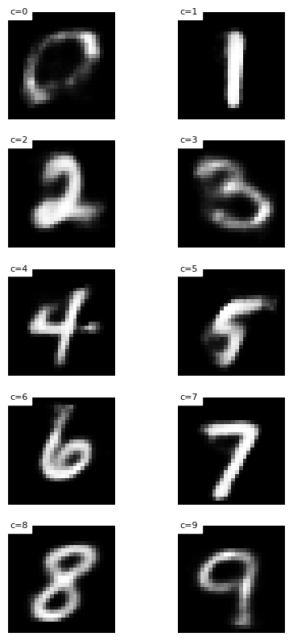

```python
# Prob1-9
if conditional:
    c = torch.arange(0, 10).long().unsqueeze(1).to(device)
    z = torch.randn([10, nz]).to(device)
    x = cvae_model.decoder(z, c=c)
else:
    z = torch.randn([10, nz]).to(device)
    x = cvae_model.decoder(z)

plt.figure()
plt.figure(figsize=(5, 10))
for p in range(10):
    plt.subplot(5, 2, p+1)
    if conditional:
        plt.text(
            0, 0, "c={:d}".format(c[p].item()), color='black',
            backgroundcolor='white', fontsize=8)
    plt.imshow(x[p].view(28, 28).cpu().data.numpy(), cmap='gray')
    plt.axis('off')
```

# Submission Instructions

You need to submit this jupyter notebook and a PDF. See Piazza for detailed submission instructions.